# Introductory Statistics with Randomization and Simulation: Chapter 4

## The Bootstrap (ctd.)

Once we have a new, sampled with replacement, sample, we compute our test statistic again on the new sample.

Iterate this process * Sample with replacement \(N\) times, compute the test statistic * Do the entire process again * And again …

This gives the **bootstrap distribution** of the test statistic.

## Example: Amazon Book Prices

```r
data(textbooks, package = "openintro")
sd(textbooks$diff)
```

```
## [1] 14.255
```

This is the data set from Chapter 4.2: some prices on textbooks from Amazon.com and a university bookstore. We have 73 observations of textbook prices, with standard deviation 14.255.

## Example (ctd.)

We can sample from this data set of 73 differences, repeatedly.

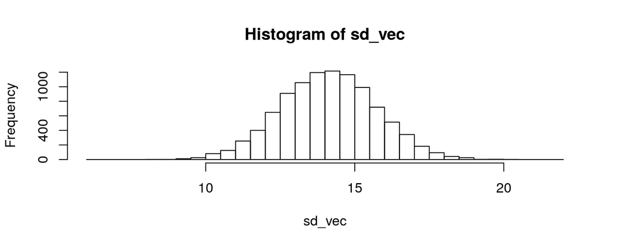

```r
sd_vec <- vector(length = 10000)
for(j in 1:10000) {
  sd_vec[j] <- sd(sample(textbooks$diff, size = 73, replace = TRUE))
}
hist(sd_vec)
```

## Example (ctd.)

The bootstrap distribution is symmetric, bell-shaped, and centered at 14.12, near the standard deviation of the textbook data, 14.255.

- The standard deviation of the bootstrap deviation is 1.587.
- We can then use this to quantify the uncertainty of the point estimate
- This is the **bootstrap estimate** of the **standard error** (SE)

## Conditions for using Bootstrap for Inference

If

- the observations in the original sample are independent
- the original sample size \(N \geq 30\)
- the bootstrap distribution is approximately normal

then the bootstrap distribution for the standard deviation will be a good approximation of the sampling distribution for the standard deviation.

## Third Condition

How do we check that the bootstrap distribution is approximately normal? **Use a Q-Q plot**!

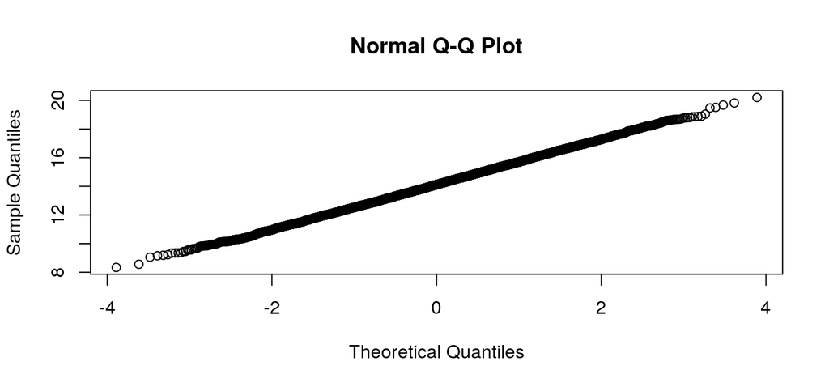

```r
qqnorm(sd_vec)
```

## Confidence Interval

Once we have the conditions met, we can do standard techniques that require normality: compute confidence intervals, perform inference, etc.

We use the same formula as before:

\[ \text{point estimate} \pm t_{df}^* \cdot \text{SE} \]

Since we have \(N = 73\), this gives \(df = N-1 = 72\). Then,

```r
qt(0.975, df = 72)
```

```
## [1] 1.993464
```

## Confidence Interval

We then compute a 95% confidence interval for the standard deviation of the differences in textbook prices:

\[ \begin{split} \text{point estimate} &\pm t_{df}^* \cdot \text{SE} \\ 14.26 & \pm 1.9935 \cdot 1.587 \\ (11.096, &17.424) \end{split} \]